# Family Fortunes: A Quantitative Analysis of the Early Iron Age Cemeteries at Knossos, Crete

Dominic Pollard, Institute of Archaeology, University College London

dominic.pollard.16@ucl.ac.uk

01 April, 2019

Abstract

Three principal interests converge in this paper: reorienting the focus of Early Iron Age Cretan archaeology; the application of computational, and quantitative methods to supplement traditional modes of inference; and open-access data and reproducible research. The Early Iron Age cemeteries of Knossos, Crete, represent the richest source of archaeological material at the site for the whole period between the end of the Bronze Age and the emergence of the Archaic *polis*. However, despite well-published excavation reports on the two largest burial grounds, the Fortetsa and Knossos North cemeteries, and a number of studies dealing with various artefact classes and individual tombs therein, no substantial comparative, quantitative analysis of these two cemeteries has yet been undertaken. This paper provides such an analysis, examining both the synchronic and diachronic variation among the tombs in these two cemeteries. Through the application of a range of quantitative techniques, this study isolates a pattern of increased rates of burial among a few select tombs, and further considers their characteristics. This paper demonstrates the potential for quantitative analyses to contribute to nuanced, context-specific theories of social practice, and advocates their wider application to the archaeological record of the Cretan Early Iron Age. It also serves as a demonstration of maximal research reproducibility, with the full datasets and code underpinning the analysis made freely available to download and use.

# 1 Introduction

It may be felt that, of all ancient sites on Crete, Knossos is the last in need of further archaeological attention. The city and ‘palace’ of Knossos, first excavated well over a century ago (Evans 1921; 1928; 1930), retain a pre-eminent position in popular and academic accounts the island’s Bronze Age, and few, if any, other Cretan sites have been so thoroughly dug, reconstructed, and contested. However, there are reasons why the present study – a quantitative comparison of the two largest Early Iron Age cemeteries at Knossos – is not only justified, but also timely.

For one, this is not the Knossos of that illustrous, palatial period, but rather the town as it persisted and evolved during the subsequent Early Iron Age (EIA), about which much less is known. Research into this once maligned period has grown apace in the last few decades. What began as a reframing of the the twelth-seventh centuries as the gestational period of the later classical Greek world (first seen in the works of Coldstream 1977; Desborough 1972; Snodgrass 1971) has culimated in the complete rejection by many scholars of the image of a society bereft of its former palatial glory. Certainly, few would any longer defend the appelation or interpretive bagguage of the ‘Dark Ages’ (on the origins of which, see Kotsonas 2016; Morris 1997).Nonetheless, our knowledge of many EIA settlements (both new foundations, and those with BA ancestry like Knossos) remains often underdeveloped in comparison with those of the second millennium BC.

Secondly, and welcome though they are, a number of recent publications on the socio-economic (Wallace 2010) and settlement (Nowicki 2000) changes which accompanied the BA-EIA transition have directed scholarly attention toward a number of elevated, defensible settlements supposedly founded in response to the turbulent contemporary political climate. This research agenda is likewise reflected in survey work, which has focussed extensively around the Bay of Mirabello, and the Isthmus of Ierapetra. This has, unfortunately, engendered a certain disregard for continuing occupation at several lowland centres in the central region of the island, including Knossos and Phaistos. There remains, therefore, a need for studies addressing the social dynamics at these sites, with a long-term view to comparative appraisal of the divergent trajectories of communities across the island in the EIA (Whitley 2011, 667–668).

Finally, a number of authors, drawing on datasets from Crete and the wider Aegean, have in recent years demonstrated the great potential of quantitative, statistical, spatial, and network analyses to elucidate social dynamics, settlement patterning, and systems of inter-regional communication and exchange. Such work encourages the use of large (and often pre-existing) datasets, and the sharing of both data and methods to facilitate reproducible, collaborative, and innovative research. The cemeteries of Knossos offer an opportunity to introduce such approaches into EIA research, where they have yet to make much of an impact (see Kotsonas 2011). The Fortesta and North Cemetery complexes are both well-published (Brock 1957; Coldstream and Catling 1996) and have been considered variously in relation to their “oriental”" imports (Antoniadis 2012), antiques (Crowe 2016), and religious context (Coldstream 1984a). But a lack of quantitative analyses, or systematic comparisons between different cemeteries, has left us with many intuited trends, some clearly exceptional tombs, but a general impression of un-patterned multiplicity.

I suggest that the application of a range of quantitative and statistical methods may provide new insight into the social behaviours underlying the mortuary assemblages. With a dataset including information on every find and tomb recorded in the Fortetsa and Knossos North Cemetery publications (Brock 1957; Coldstream and Catling 1996), the following analysis examines both the synchronic and diachronic variation among the tombs of both cemeteries. In doing so, I aim to demonstrate the potential for quantitative methods, firstly, to permit more reliable identification, and more nuanced characterisation, of significant patterning in the archaeological material; secondly, to facilitate a more systematic appraisal of the cemeteries’ largest tombs, and set their development in a richer socio-economic context; and, finally, to offer not just generalities, but evidence by which to consider, in tangible and context-specific ways, the motivations and identities of the burial groups themselves.

# 2 Early Iron Age Knossos

## 2.1 Settlement Evidence: ‘A meagre filling in a very thick sandwich’

Settlement evidence at EIA Knossos is, in a word, insubstantial. Speaking of the town’s stratigraphic sequence, Coldstream lamented that “the remains of [this] period are like a meagre filling in a very thick sandwich” between Bronze Age and later Greek and Roman levels (Coldstream 1991, 287). Most individual finds of Protogeometric or Geometric date take the form of flimsy foundations, patches of earth floor, wells or simple scatters of pottery, and for a long time it was believed the town contracted, moved, or even dissolved following the collapse of the palace. Indeed, Alexiou (Α$\lambda$$\epsilon$$\xi$ίο$\upsilon$ 1950) thought it likely that the area comprised several dispersed villages, which later coalesced into a single city, as per Aristotle’s model of synoecism.

However, by the time of Hood and Smyth’s (1981) survey-cum-synthesis of prior excavations, a concentration of activity slightly to the west of the old palace presented a good case for continuing, nucleated settlement, something strongly advocated by Coldstream (1984b; 2000). More recently, the findings of the Knossos Urban Landscape Project suggest a PG settlement of up to 40ha, extending from the Kairatos River to the western slope of the Acropolis, and from the northern slope of Gypsades to between the Minoan palace and the Kephala hill (Kotsonas et al. 2011, 5–8). This estimate remains our best guess in the absence of substantial excavatied deposits but, if it is accurate, then EIA Knossos was one of the largest sites of the contemporary Aegean, and we should expect the existence of relatively complex forms of social interaction and organisation within this exceptional community.

## 2.2 The Early Iron Age Cemeteries

Survey aside, our most abundant evidence for EIA Knossos comes from the mortuary record. The transitional period between the LBA and EIA, admittedly, yields few if any securely datable burials. In the EIA proper, however, the evidence becomes more plentiful, with multiple burials known from the Kephala ridge (Coldstream 1963, 38; Hogarth 1899, 82–85), the modern suburbs of Ayios Ioannis and Atsalenio (Boardman 1960; Davaras 1968, 133–146), the cave of Mavro Spelio (Antoniadis 2012, 58–59), and the Khaniale Teke site with its well-known tholos, mooted as evidence for the presence immigrant craftsmen from the Near East (Boardman 1967; Hutchinson and Boardman 1954; cf. Hoffman 1997 Kotsonas (2006)). Taken together, these scattered tombs point to a variegated set of funerary practices, all within about 30 minutes’ walk of each other, each serving some sub-section of the Knossian population. But despite their reasonable number when considered collectively, these tombs, so dispersed and often solitary, provide little scope for systematic quantitative analysis.

Fortunately, far larger burial accumulations are to be found in the Fortetsa and the Knossos North cemeteries, which together comprise some 134 tombs, ranging in date from the Subminoan to Late Orienatalising periods – a span of around 400 years. Though many were robbed in antiquity, and others destroyed by the digging of later burials, building work, or just the ravages of time, they still represent the most comprehensive and abundant source of evidence for not just mortuary practices, but for social life of any kind at EIA Knossos. They are thus the ideal candidates for a quantitative analysis of the kind advanced here.

## 2.3 The Fortetsa and the Knossos North Cemeteries

The cemetery on the slope facing the eponymous village of Fortetsa is composed of twelve tombs excavated in 1933, and another eight uncovered in 1935 (Brock 1957, xi). These tombs cluster in three main groups. The largest of these, including tombs IX, VIII, VII, V, II, III, IV, V and P, is arranged on a north-south axis, with the *dromos* of each tomb extending downslope to the west (Tomb P is set on a slightly different orientation, though, as we shall see, this tomb is particularly exceptional). Further north lies the cluster of tombs OD, X, XI, LST and BLT. The third group lies south of the first, and comprises tombs Θ, Ϙ and F. Finally, three tombs excavated in 1933 – L, TFT and Π – which lie close to the main road north of the Acropolis hill (Brock 1957, 1–2) are now considered to belong the Knossos North Cemetery.

To the northeast of the Fortetsa cemetery, a collection of ten badly damaged tombs known, after the year of their excavation, as the Fortetsa 1967 tombs, were probably the southernmost burials of the North Cemetery. Unfortunately, all had been looted at the time of excavation, and no in situ deposit was found in any tomb. For this reason, unfortunately, they feature little in the present analysis. Northwest of these tombs, and just south of the Teke Tholos, the Teke tombs represent the northern reaches of the KNC. The Teke tholos itself, and the tombs around it, were almost certainly part of the same complex, with six unpublished tombs excavated by the Archaeological Service during the construction of intervening buildings in the 1980s. The central section of the KNC comprises the ‘Medical Faculty’ site, so named because it was the construction of an extension for the university of Crete that prompted major rescue excavations here in 1978. Some 89 tombs of Subminoan to Late Orientalising date were found, by far the largest single concentration of EIA tombs in the whole Knossos area (Coldstream and Catling 1996, 53–55).

The 134 tombs that make up these two cemeteries, some of which were in use for several centuries, suggest an established, relatively stable community for whom tradition formed an important foundation in mortuary beliefs and behaviours (Coldstream 1994, 106–108). The tombs fall into three main types, the chamber tomb, shaft grave, and pit cave or tomb; the latter two are largely Subminoam phenomena, with the former by far the most abundant. The chamber tomb comprises a descending ramp or passage, the *dromos*, leading to the chamber itself, cut into the bedrock. The *dromos* and chamber are separated by the *stomion*, an opening often set a step or two lower than the *dromos*, which is covered by a large stone slab, smaller stacked stones, or a combination of both (Antoniadis 2012, 47–48). It is not uncommon for dromoi to have niches cut into them, to house later burials that could not fit in the chamber (e.g. T. II), or even, in some cases, cinerary urns removed from the chamber so that new interments could be fitted in (e.g. T. TFT; Brock (1957), 3-4).

The majority of burials in these two cemeteries are cremations, a rite that appears at Knossos in the Subminoan period, in the Tomb 200+ complex (Ts. 200, 201 and 202 are three chambers of a single pit tomb) in the KNC (Coldstream 1994, 109). Inhumation does not completely disappear in the EIA, but by the Orientalising period it appears restricted to child burials, and in those instances where it is attested (Ts. L, 45, 98, 112 and F67:5), these burials appear to be among the very earliest in each tomb (Antoniadis 2012, 69). This degree of coexistence suggests that the shift between the two rites need not have marked a major ideological break; the preference for communal chamber tombs, for instance, something practiced since the Middle Minoan period at Knossos, remained constant. Whether this is linked to a strong sense of historical continuity or tradition, close kinship ties, or simply the need to bury large numbers of people in a small geographical area, we cannot be sure.

## 2.4 Chronological developments in the cemeteries

The chronological sequence of the cemeteries has received much attention. It has been claimed that no tomb crosses the LM IIIC-SM divide [Coldstream (1998), 58; Coldstream (2006), 582), but there is a strong possibility that this is a classificatory artefact (Hallager 2010). The earliest tomb appears to be the T. 200+ complex, with its precocious cremations and imported artefacts. There remain ongoing debates about whether the KNC represents a foundation on virgin soil, as instances of BA tombs reused the EIA are known (e.g. the Khaniale Teke tholos). Cavanagh (1996), for one, could not rule out the possibility of some KNC tombs being of BA date based on his cluster analysis, but other evidence would suggest this is unlikely.

The final mystery of the chronological sequence at the KNC and Fortetsa is the quite abrupt cessation of new burials around 630 BCE. There had been changes in tomb use in both cemeteries in the preceding century, with no new tombs built in Fortetsa, and few in the KNC, though interments in old tombs continued [Brock (1957), 4; Cavanagh (1996); 651-3]. This curiosity has, along with the equally scanty evidence for the period in the wider settlement, become known as the ‘Archaic Gap’. The causes of this lacuna, which persists until the recrudescence of archaeological evidence in the Late Archaic period, remain unknown. Although various explanations have been forwarded, (Coldstream, Huxley, and Webb 1999, 301–302; Huxley 1994, 126; Kotsonas 2002, 41–44), it seems there are now strong reasons to doubt the settlement was truly abandoned (Whitelaw, pers comm.).

## 2.5 Heroes and Heirlooms: Object Biographies and Exceptional Burials

A popular approach to the study of Knossos’ EIA tombs has been the investigation of ‘object biography’, a term derived from Appadurai (1986) and Kopytoff (1986). Influenced by Mauss’ (1954) formulation of ‘the gift’, these authors stressed the mutuable nature of an object’s social meanings, and its capacity for acquiring a ‘biography’, through the transformations of its social existence. In Aegean archaeology, these ideas proved attractive because of their resonance with the Homeric motif of gift-giving accompanied by accounts of an object’s illustrious heritage (Whitley 2002, 220–221). It is hardly suprising that, when direct parallels for such objects have appeared archaeologically – such as the boar’s tusk helmet from Tomb 200+ and that given to Odysseus by Meriones (*Iliad* 10.260-271) – a particular interpretive lens, melding Homeric and anthropological ideas, has been applied to certain elaborate burials.

Catling’s discussion of the T. 200+ complex is a notable example. Tomb 201 contained the remains of at least two adults, and possibly a child. The burial objects included a bronze sword, spearhead, and arrowhead, an iron dirk or knife, fragments of an antique bronze stand, probably of Cypriot origin, and pieces of the aforementioned BA-style boar’s tusk helmet (Catling 1995, 123). Catling identifies similarities between this tomb and burials at Tiryns, Kaloriziki, and the famous *hērōön* of Lefkandi. All contained imported items at an early date, were of ‘warrior grave’ type, and formed loci for later burials. Catling argues that those individuals who dared to travel abroad in this time of more limited seafaring, accruing with precious artefacts and stories of distant lands – ‘heroes returned’ in Catling’s phrase – would have been accorded exceptional treatment in death (Catling 1995), 127–8].

Complementing the theme of heroes abroad has been a similar degree of interest in foreigners at home. Two caches of gold jewellery, found in pits flanking the entrance to the Teke Tholos, were argued by Boardman (1967) to be foundation deposits – a known Near Eastern custom – for the burial place of an immigrant craftsman, probably Phoenician, practising his trade at Knossos. Kotsonas has revisited this attribution, suggesting that the tholos is more likely the resting place of an elite individual or family with a monopoly over a metal workshop’s output (2006, 155–159). While certainty in such individual cases may be moot, it seems unlikely that traders or craftsmen of non-Cretan heritage never visited or resided at Knossos during the EIA (Hoffman 1997, 176–185; Schreiber 2003, 293–306).

Finally, a recurrent interest has been in the ‘presence of the past’ in these tombs. The practice of hero or ancestor cult, much discussed on the mainland (see Antonaccio (1994); Coldstream (1976)), is not common here. Instead, we see several Late Minoan larnakes (and a few other vessels) redeposited in tombs and pits in the KNC and Fortetsa from the PGB period onward. A thorough analysis of these artefacts has been provided by Crowe (2016), who argues that the larnakes were robbed from tombs in the Knossos area, perhaps with a particular preference for painted specimens where available. A particularly evocative case comres from tomb 107, where parts of an elaborate figured LM larnax have been found along with a PGB vessel by the so-called Tree Painter. Both feature women in the company of birds and spiralling trees, and it seems certain that the former inspired the design of the latter. The PGB vessel also seems to draw on Oriental motifs, with the polos crown worn by the goddess having Near Eastern origins (Coldstream 1984a, 94–101). The magpie-like amalgamation of these styles and motifs seem to exemplify the particular cultural openness, fluidity and competition suggested to characterise the PGB period. Artefacts such as this hint towards an intimate discourse of (re)discovery; a painter, struck by the strangeness, or perhaps the uncanny familiarity, of centuries-old images, incorporated them into his own work.

## 2.6 Number Crunching: Quantitative Analyses of the Cemeteries

Generally speaking, the above analyses have tended to rely more on particular finds, single tombs, or observable, but limited, patterns in the data to form their conclusions. A few authors have applied more quantative approaches, and these point toward their potential utility. Antoniadis (2012, 172–176), in his study of Oriental imports, divided the EIA tombs of Knossos into three groups, those with fewer than 10 pots, fewer than 50 pots, and more than 50 pots, and found that, in each successive case, the proportions of tombs containing imports and imitations increased. The implication is that a hierarchy existed, with differing degrees of control over the accumulation of prestigious goods. That said, the relationship between such items and tomb ‘wealth’ is examined critically in the present work, and may prove more complex than Antoniadis implies.

Cluster analyses have been employed by both Cavanagh (1996, 653–657) and Antoniadis (2012, 193–197), the most sophisticated statistical techniques so far applied to the present material. Cavanagh’s analysis of tomb architecture has been mentioned, while Antoniadis’ more holistic approach corroborates quantitatively some of the intuitive correspondences noted between specific tombs in previous studies. Antoniadis does not interrogate his findings as much as he might have, but his highlighting of the relationship between tomb foundation dates, associated finds, and geographical location points towards social processes of self-definition and exclusion among the burial groups that would reward further investigation, something offered by the present study.

# 3 Methods

## 3.1 Databases

The cornerstone of the present study is a database (or, rather, three linked databases) based on the excavation reports for the Fortetsa and Knossos North cemeteries (Brock 1957; Coldstream and Catling 1996). The first database includes an entry for each individual ceramic vessel, by far the largest portion of all known finds. Each entry includes: the tomb from which the vessel came; the vessel shape; whether it was an open or closed vessel; its main dimensions; its ceramic period and corresponding absolute dating measures (see below). In addition, all imports, Oriental imitations, and antique (that is, Bronze Age) artefacts were accordingly categorised, using the studies of Antoniadis (2012), Jones (2000), and Crowe (2016) to supplement omissions in the original excavation reports. In total, this database comprised just over 4540 individual artefacts.

The second database is similar, but with each entry corresponding to a find other than a ceramic vessel. The categories remained the same as in the pottery database, but with the addition of a ‘material’ variable, as of course these finds were not all made of the same substance. This database included some 1620 individual artefacts. The final database concerns the tombs themselves. Each of the 134 tombs was accorded its own entry, with variables including dating (both in relative and absolute terms), surviving dimensions, and the known and estimated number of interments. Each entry also included a tally of the objects recorded in the other two databases. These tallies were arranged by shape for the pottery, and by material and category (e.g. weapon, adornment, seal, funerary paraphernalia) for the other objects. Finally, the total number of imports, imitations and antiques in each tomb was calculated.

Taken together, these databases constitute a detailed record of all the finds from the Fortetsa and KNC excavations, and offer the opportunity for carrying out a range of robust quantitative analyses. It must be conceded that, with many of the tombs evidently looted, dug into or destroyed over the centuries, this cannot be a complete picture of the tombs’ original contents. If we assume, though, that natural or accidental destruction was relatively indiscriminate, and that, even in cases of looting, certain object classes (particularly cinerary urns) were seldom robbed, then the data are by no means rendered useless. As Snodgrass (1996) notes, the situation means we should be extremely cautious about making negative arguments – that is, conclusions drawn about the lack of features in certain tombs – but may be somewhat more hopeful in the forming of positive ones.

## 3.2 Reproducibility and data-sharing

An ever-growing number of archaeologists have begun to advocate the utility, indeed the necessity, of making available not just the data underpinning their professional output, but the full methodologies by which their analyses were conducted, and in formats which facilitate reproducibilty and further investigation. It is felt that, with the opportunities afforded by current technologies (digital databases, statistical software packages, online repositories etc.), there remain ever fewer obstacles - and excuses - preventing the full and free sharing of both data and workflows. In Marwick’s words (2017, 445), “[t]he technical problems are largely solved; the challenge now is to change the norms of the discipline to make high reproducibility a canonical attribute of high-quality scholarly work”.

There are, of course, complications to the sharing of data and methods. There are real and valid reservations around issues of copyright, the protection of sites from looting, the possibility of being scooped with one’s own data, or simply the significant investment of time demanded by the preparation of open-access research. But I would argue that the potential gains outweigh these concerns, and that research on the EIA would benefit greatly from the greater accessability of datasets and workflows.

Though not visible in the present paper, every figure and table herein was produced directly, through written code, from the raw data using R. The full code can be viewed and followed by downloading the repository from GitHub, and all the data are made available through an MIT license, which permits unlimited use, ammendation, and dissemination thereof, yet frees the present author from any responsibilty for that use, or for any perceived errors or inaccuracies in the data. It is sincerely hoped that others may find interest in, and themselves further explore and expand upon the research presented here, by downloading this compedium.

## 3.3 Estimating interments

A first important step in preparing the data for analysis was the estimation of the number of individuals buried in each tomb. The method chosen for this estimation broadly follows that of Cavanagh (1996, 659–660), who took the number of pithoi (the most common urn type) and the number of pithoi, amphorae and kraters (which were in some cases used as urns) as middle and upper estimates of the number of interments, with all securely identified interments (in the form of ashes or osteological material) being the lower limit (Figure 3.1). In the present study, the mean of these three estimates was taken, to provide a single aggregate measure for the purposes of analysis (where no interments were known, this variable was still assigned a value of “1”, for all tombs must have contained at least one burial).

[output not shown]

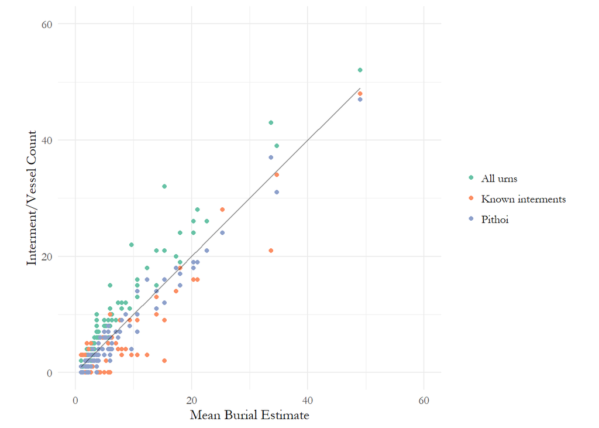

Figure 3.1: Relationship between known interments, counts of pithoi, and counts of pithoi, amphorae and kraters. The straight line represents the mean estimate based on these three values.

For most diachronic analyses, however, pithoi alone were taken as the best proxy for burial numbers, as they correlated most closely with the mean estimate, (Pearson’s *r* = 0.978565). In most cases, and often simply by virute of the methods employed, any tombs lacking identified remains or a single vessel suitable for use as an urn were not considered, thus excluding what are presumably among the most heavily damaged and looted tombs.

## 3.4 Aoristic approaches to dating

A central concern of the present study was how to deal with the temporal uncertainty implicit within the assigning of individual vessels to stylistically-defined periods. A vessel dated to the Protogeometric B period could, on our best estimates of absolute chronology, date to any point between 840 and 810 BC. This situation results in major challenges to the visualisation and analysis of such data through mean which normally rely on event- and not range-based data inputs. A simple, if unsatisfying, solution is to use the midpoint of the range asigned to each vessel (i.e. 825 for our PGB example). This method is used in a couple of instances in the present paper when the course-grained sorting of the data (into 50 year periods) renders the innacuracies of such a method less significant.

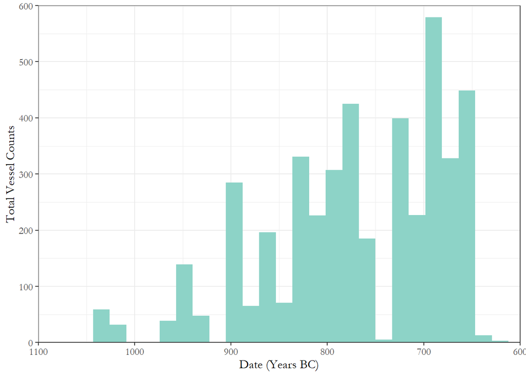

A alternative way of dealing with temporal uncertainty, and the method employed extensively in this paper, is the use of so-called “aoristic analysis”. Here, rather than assign a pot a single date, the entire timespan under investigation is divided into equal chunks (in this case, decades), and probability values summing to 1 are then assigned for each vessel, per chunk of time, based on its accordant date range. So, our PGB vessel, dateable between 840 and 810 BC would register a value of 0.33 for each of the three decades within which we it could theoretically have been produced. These values for individual vessels can can then simply be summed to produce tomb- or cemetery-level signatures. The greatest contribution of this method is that it incorporates temporal uncertainty into the size of the resulting values, that is, “events with tight temporal definition contribute more to the total probability over their range than do loosely defined events” (JOHNSON 2003 p2).

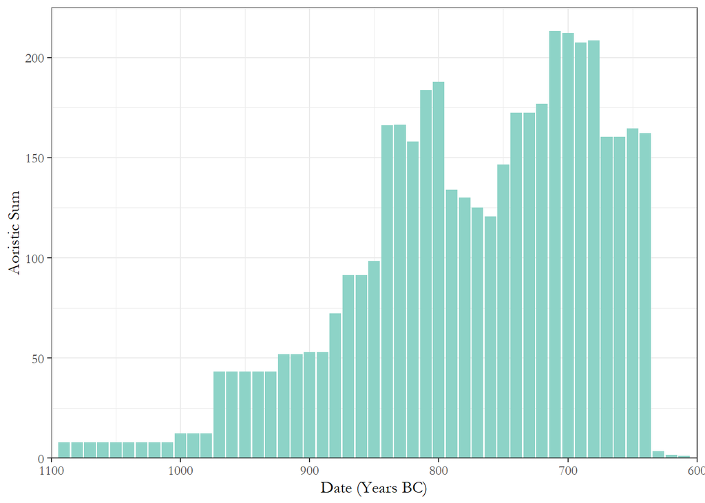

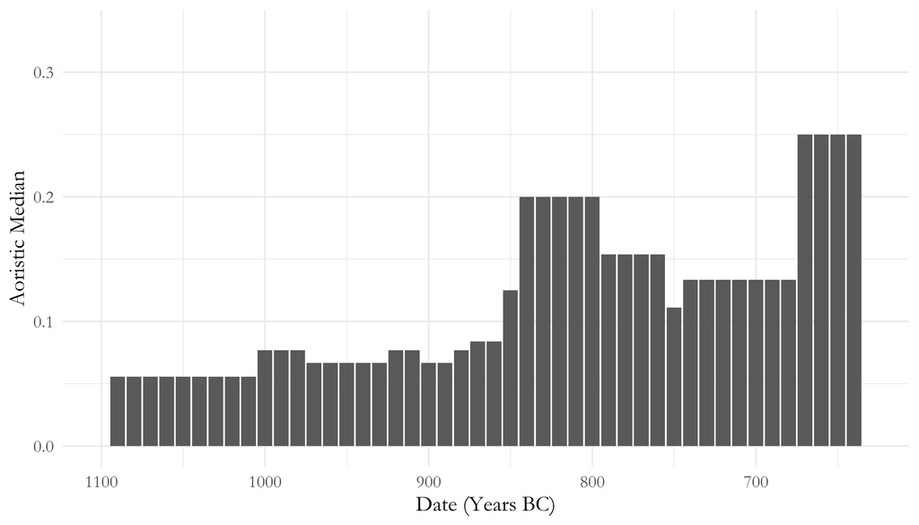

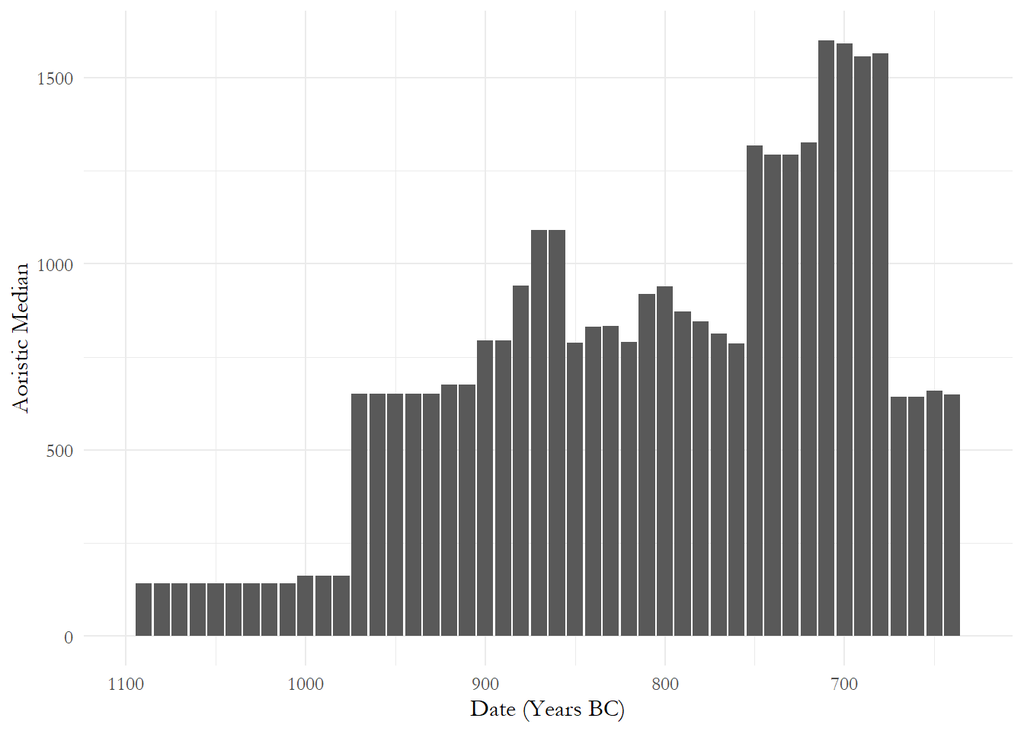

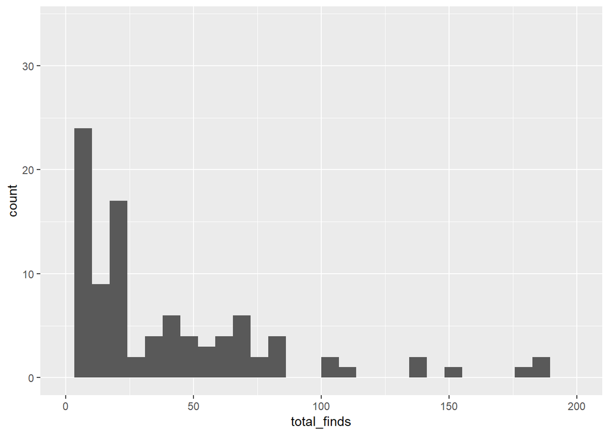

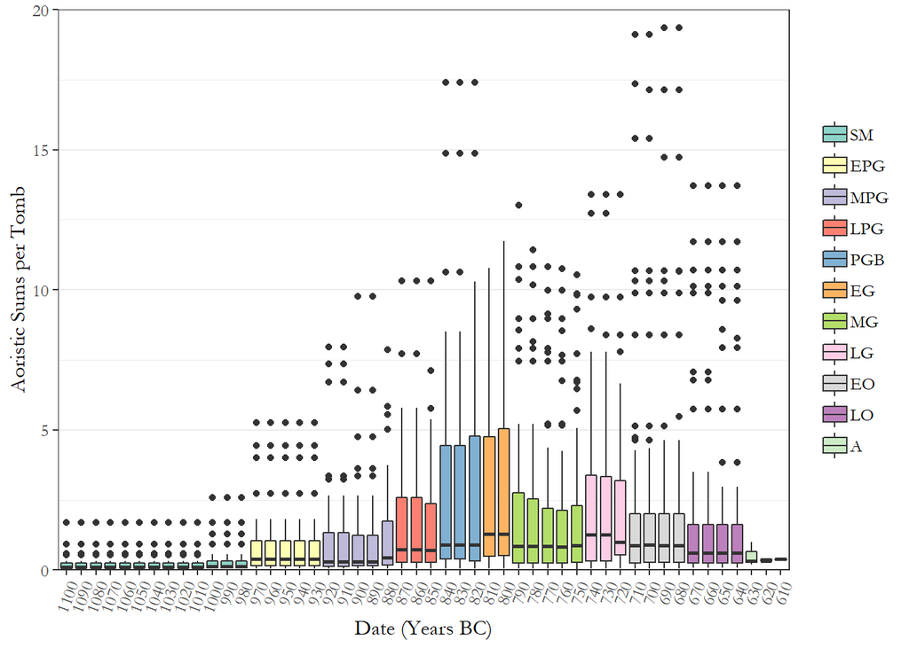

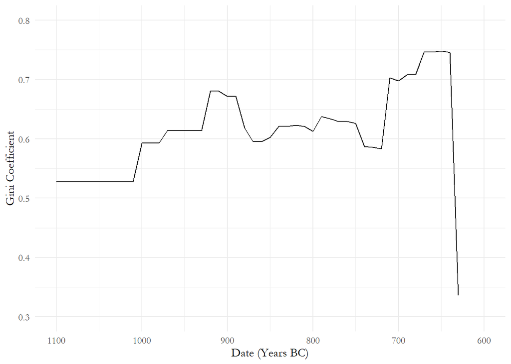

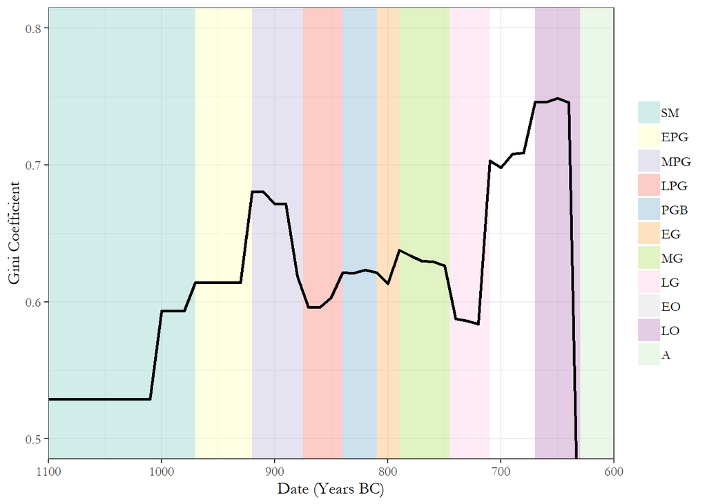

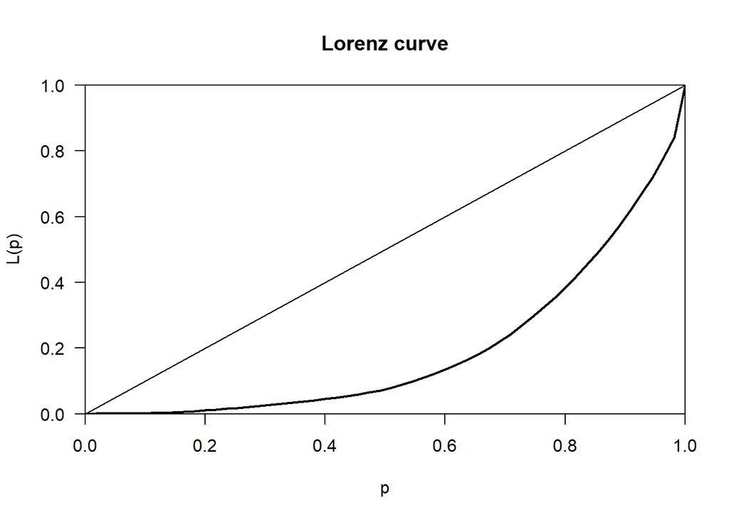

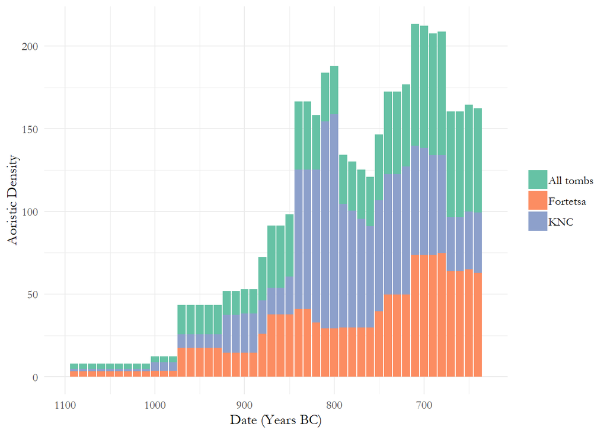

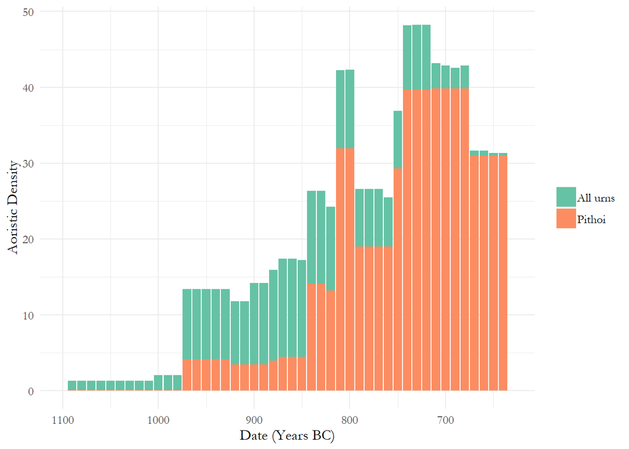

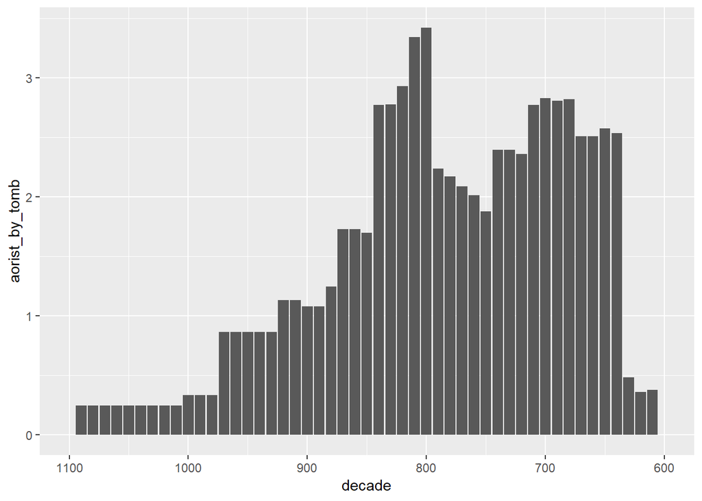

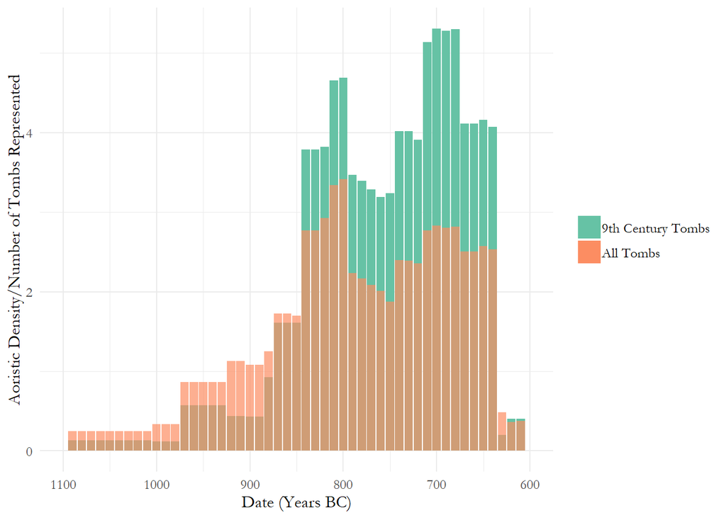

[output not shown]

[output cut: 88 more lines]

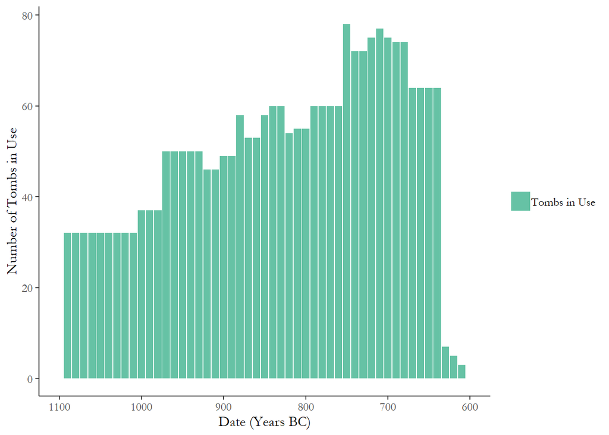

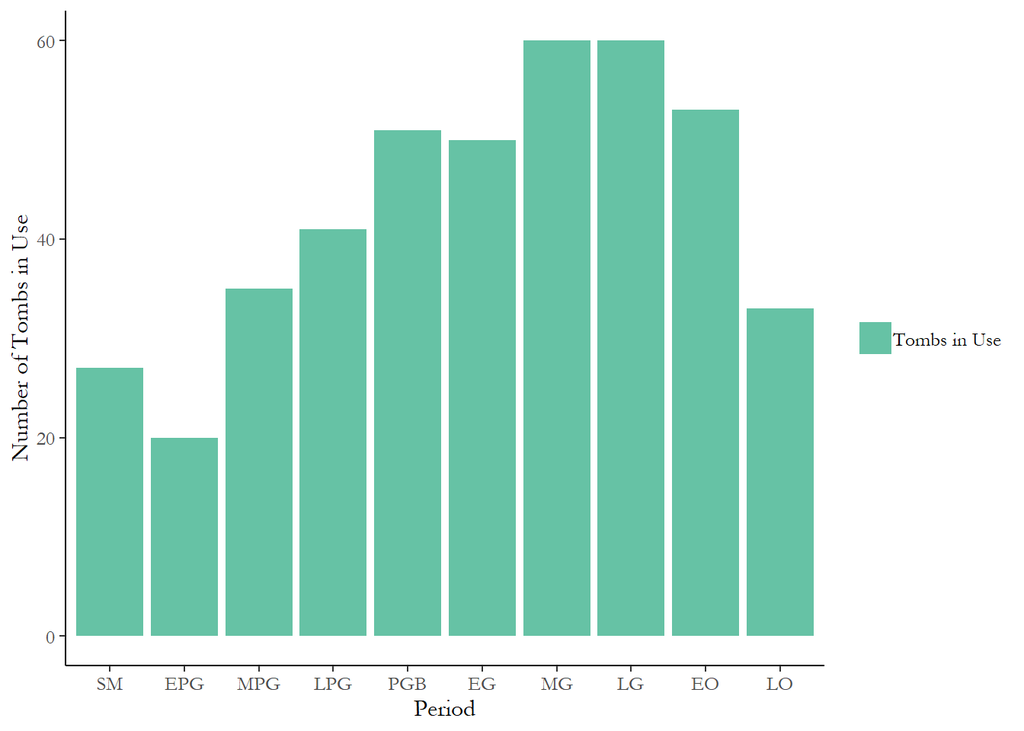

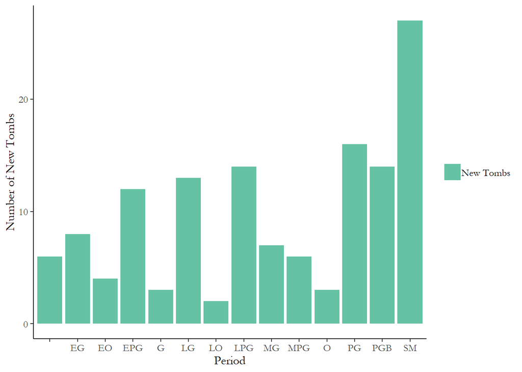

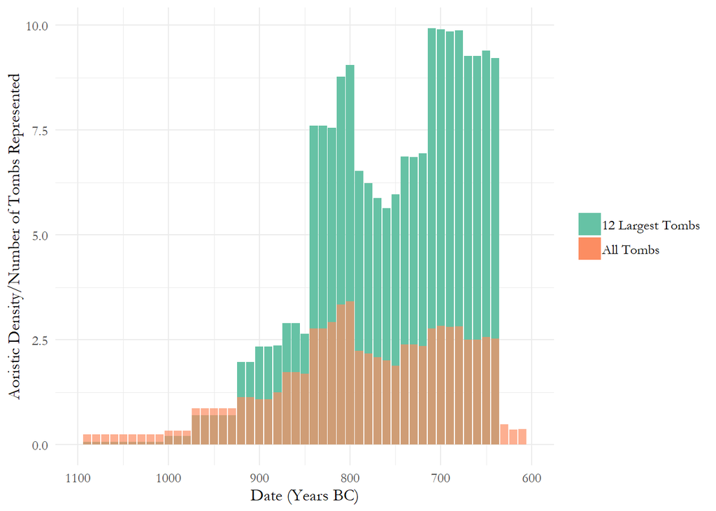